# Coronavirus in Czech Republic

# Overview

## Tests

Basic overview (Tests)

| Date | Daily tests | Cumulative number of tests | Test positivity (in %) |
| --- | --- | --- | --- |
| 2020-12-09 | 25252 | 3272143 | 25.39 |
| 2020-12-10 | 25561 | 3297704 | 22.96 |
| 2020-12-11 | 28171 | 3325875 | 22.02 |
| 2020-12-12 | 15854 | 3341729 | 23.05 |
| 2020-12-13 | 8586 | 3350315 | 23.28 |

## Decease

Basic overview (Decease)

| Date | Daily cases | Cumulative number of cases | Cumulative number of recovered | Cumulative number of deaths |
| --- | --- | --- | --- | --- |
| 2020-12-09 | 6412 | 563353 | 504698 | 9303 |
| 2020-12-10 | 5869 | 569222 | 505228 | 9406 |
| 2020-12-11 | 6203 | 575425 | 505618 | 9497 |
| 2020-12-12 | 3655 | 579080 | 505816 | 9564 |
| 2020-12-13 | 1999 | 581079 | 505922 | 9609 |

# Current situation

Active cases: `65548`

Currently hospitalized: `4203`

Proportion of infected needing hospital: `6.41`%

Mortality: `1.65`%

# SIR MODELY

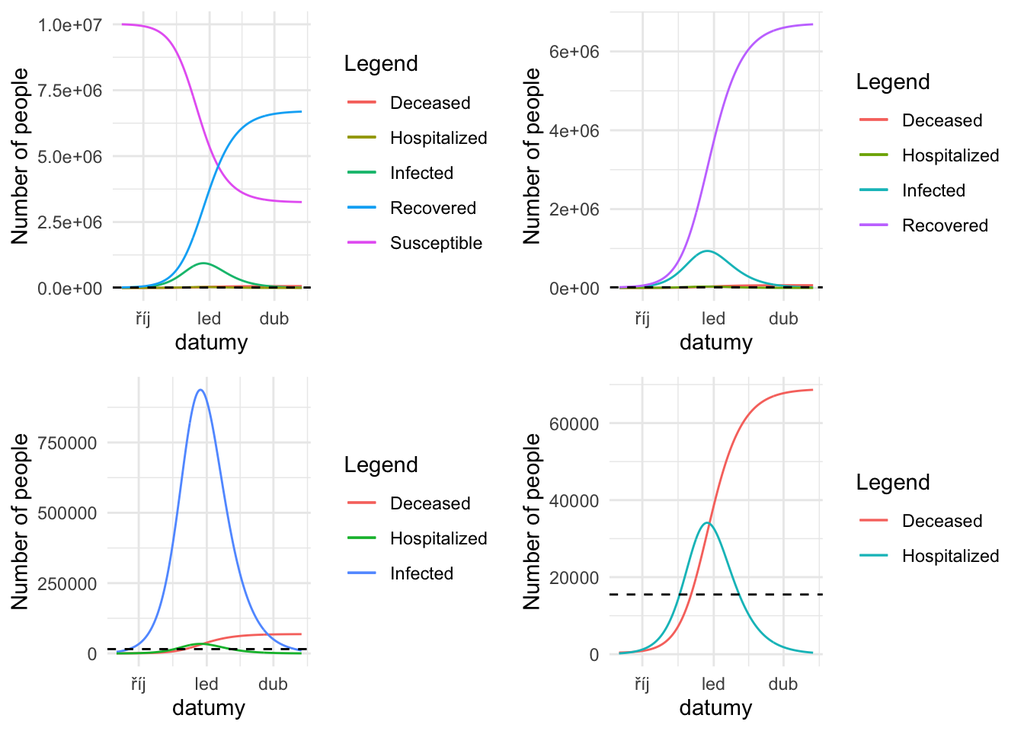

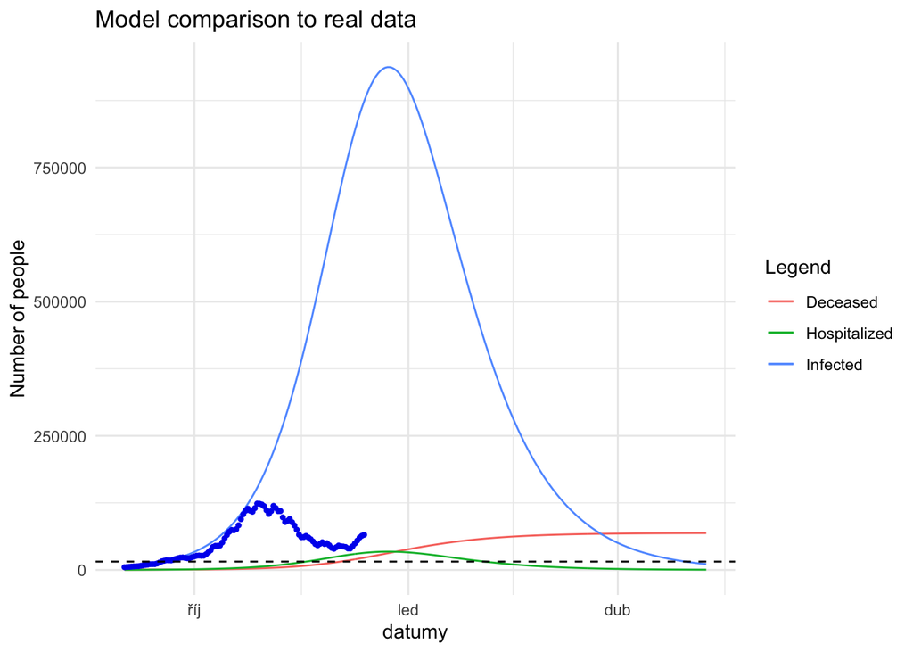

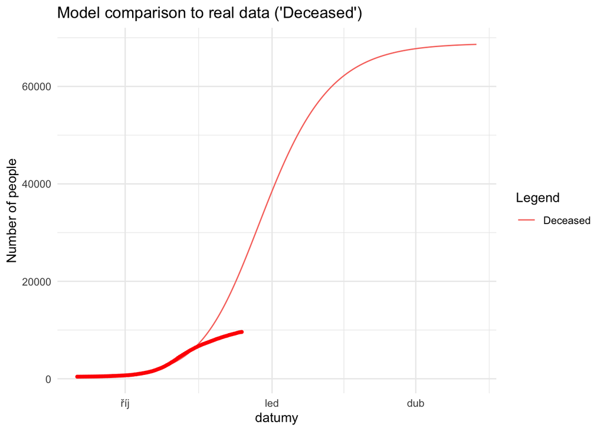

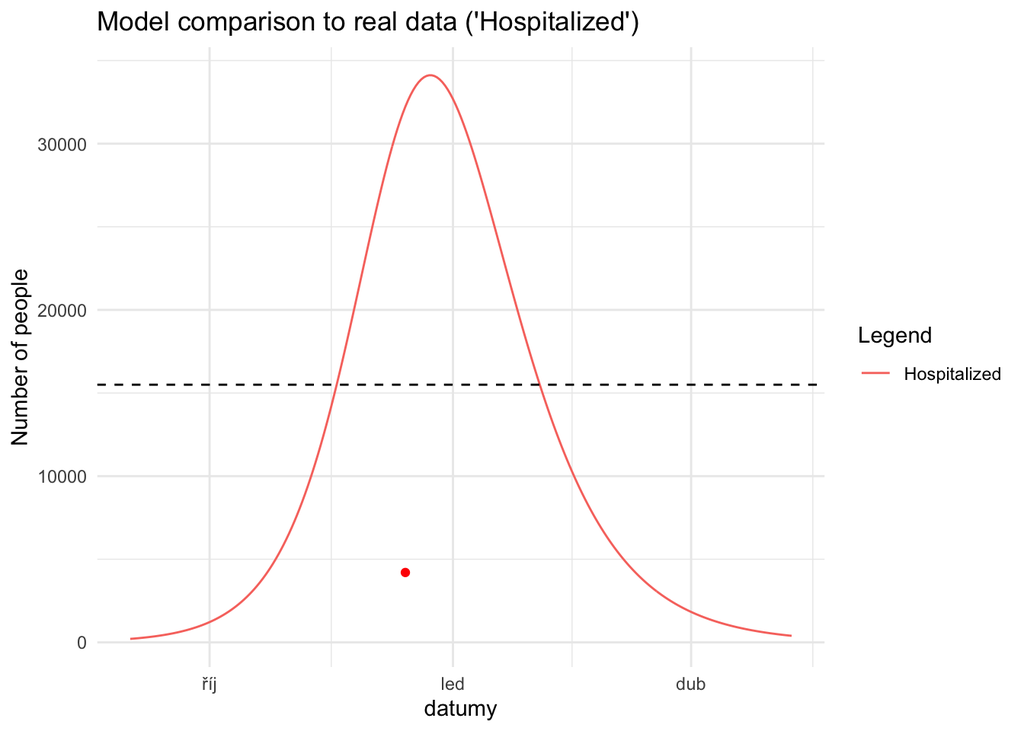

## Informace

`Peak will happen on 2020-12-23 with number of confirmed cases equal to 937231 and 34115 people at the hospital at the time.`

`Capacity of hospital, which is equal to 15500 beds, will be overreached on 2020-11-19`

`Sum of all Covid-19 cases will be 6688258`

`Number of deaths will be 68637`

`Rho is equal to 1.682`

# Basic Graphs

## Tests

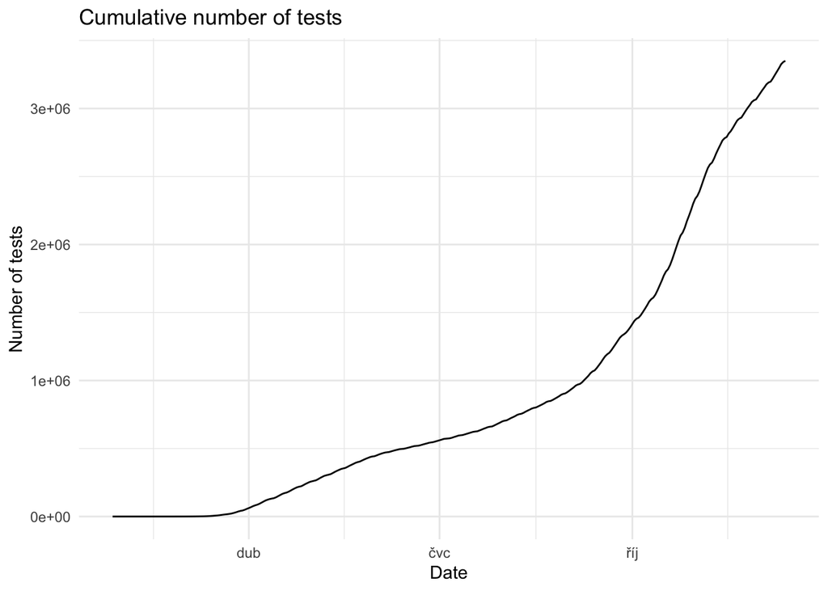

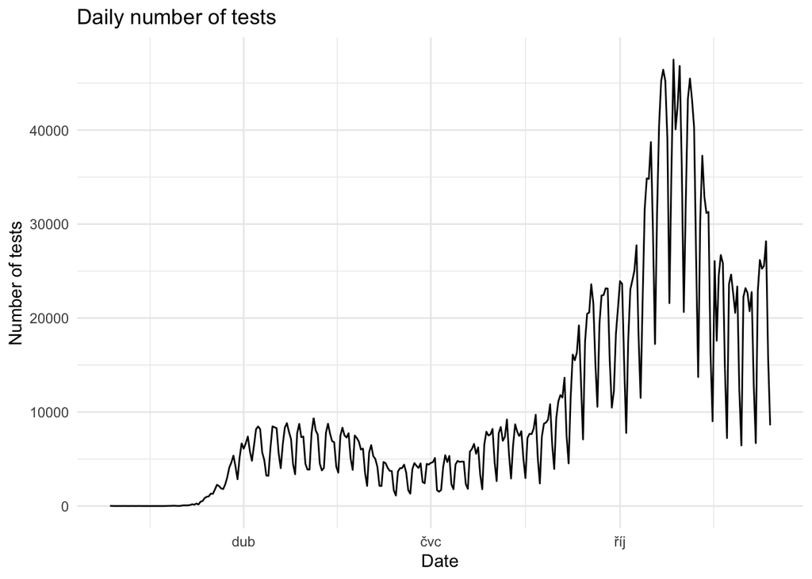

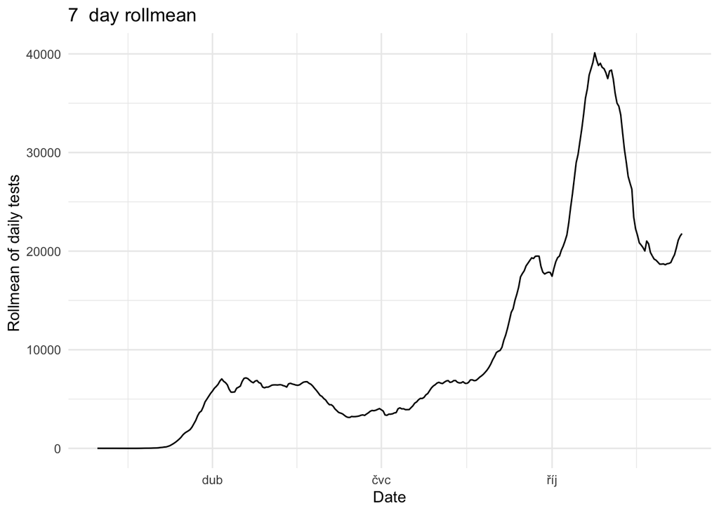

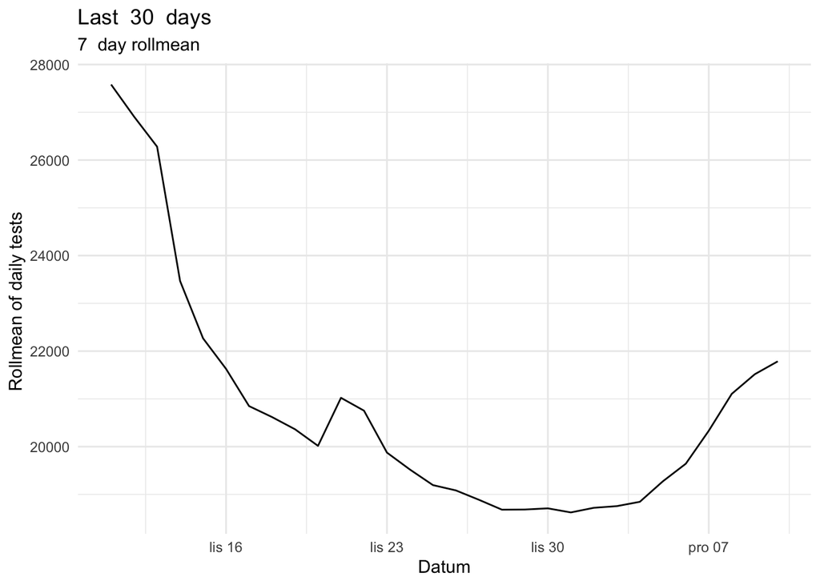

## Confirmed cases

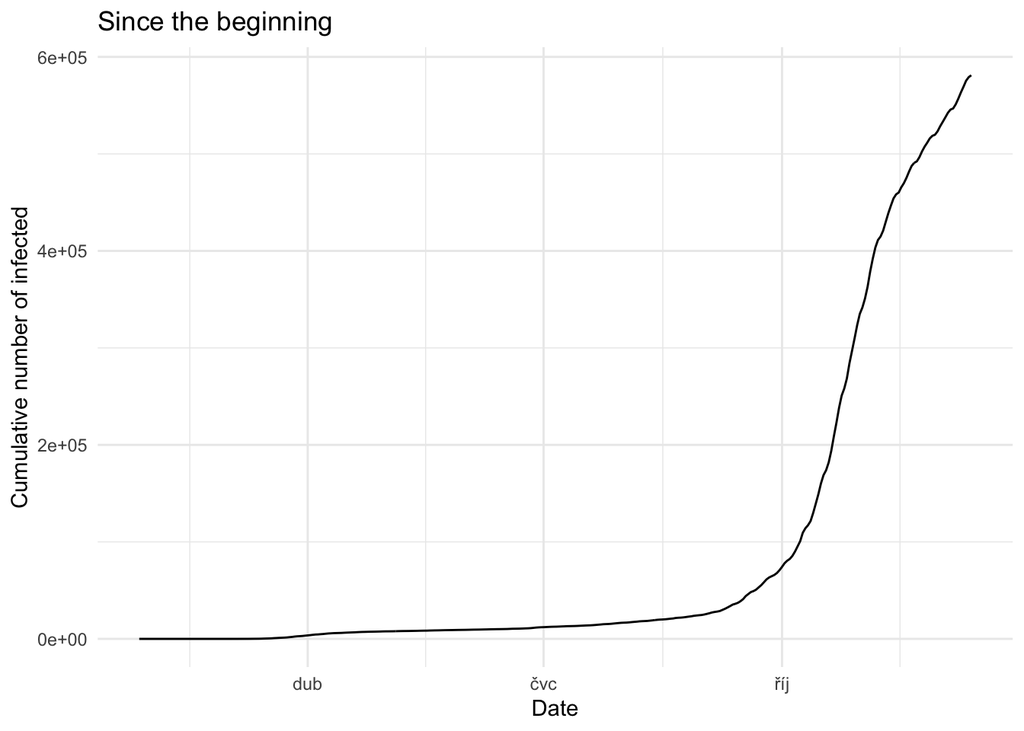

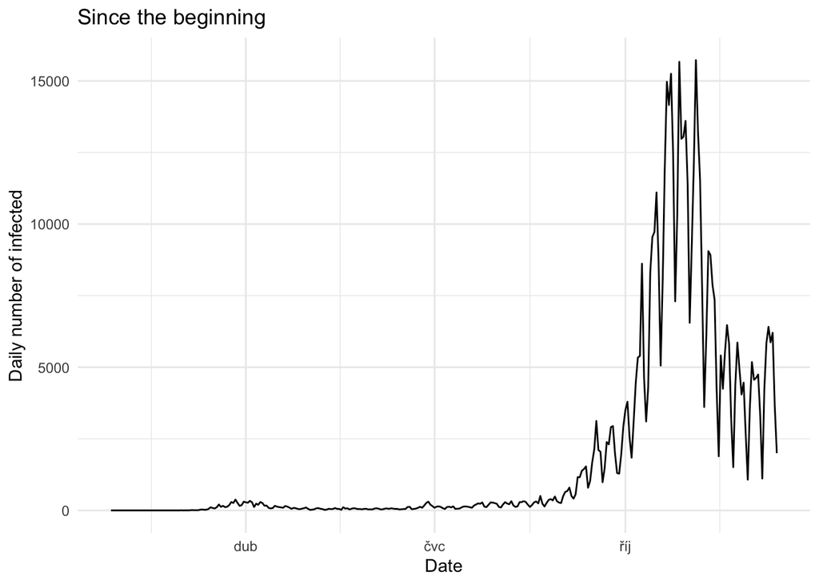

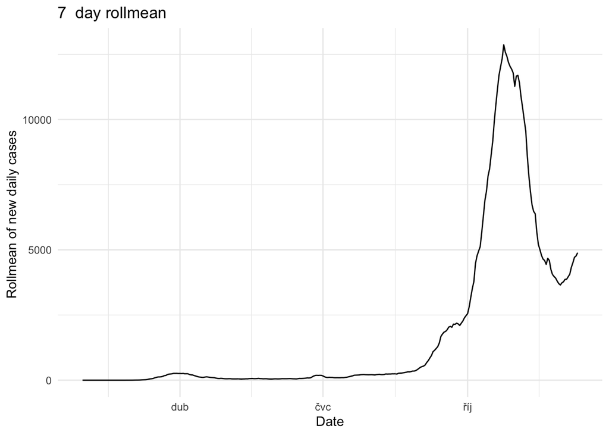

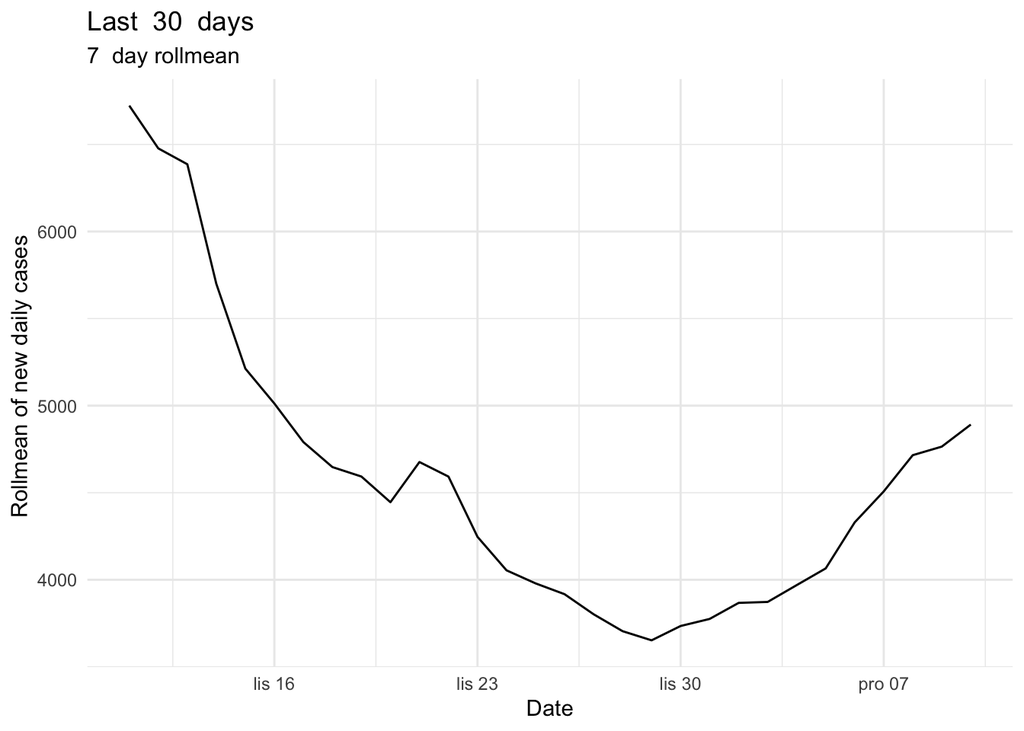

## Proportion of positive tests

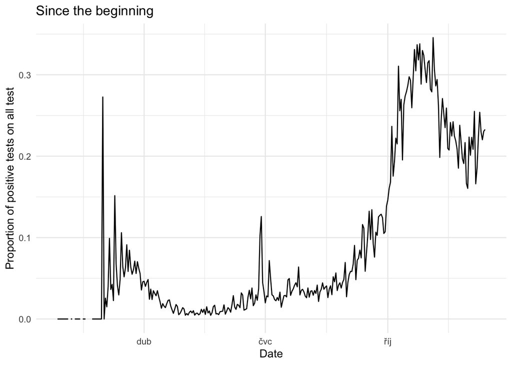

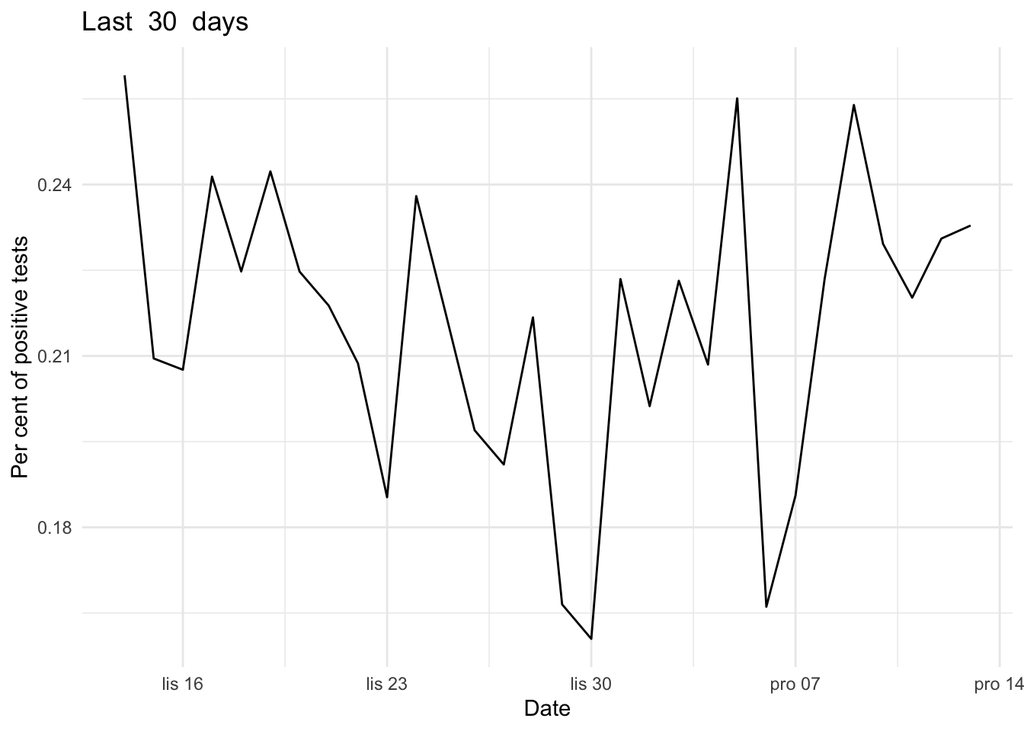

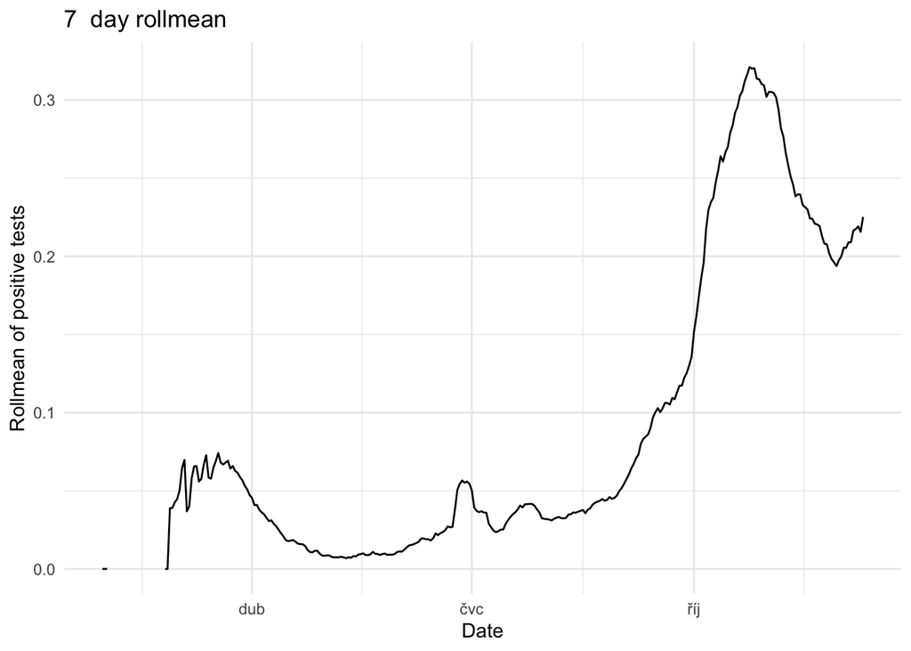

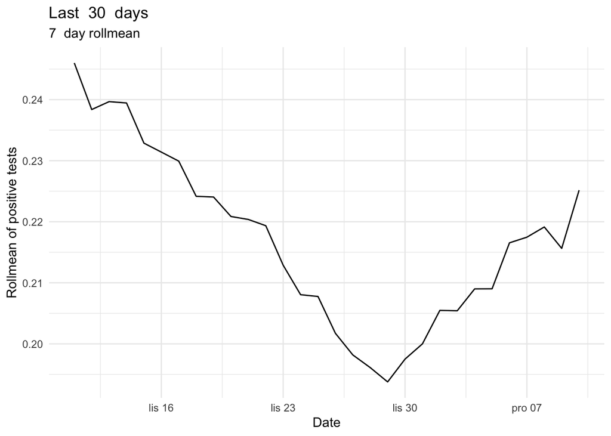

Proportion of positive tests on all tests performed since the beginning is `17.344` %.

Proportion of positive tests on all tests performed in the last 30 days is `21.705` %.

# Models

## Linear model

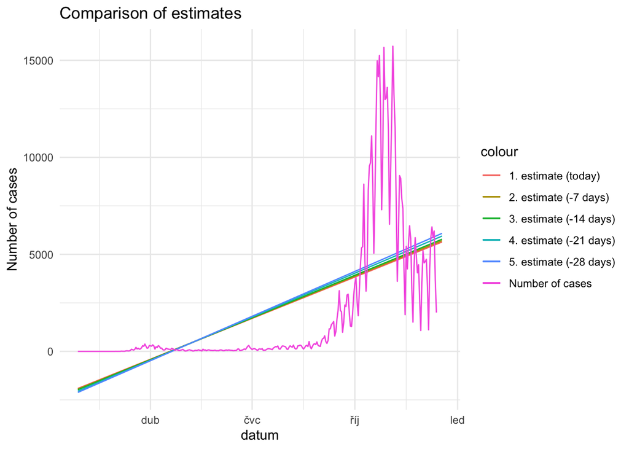

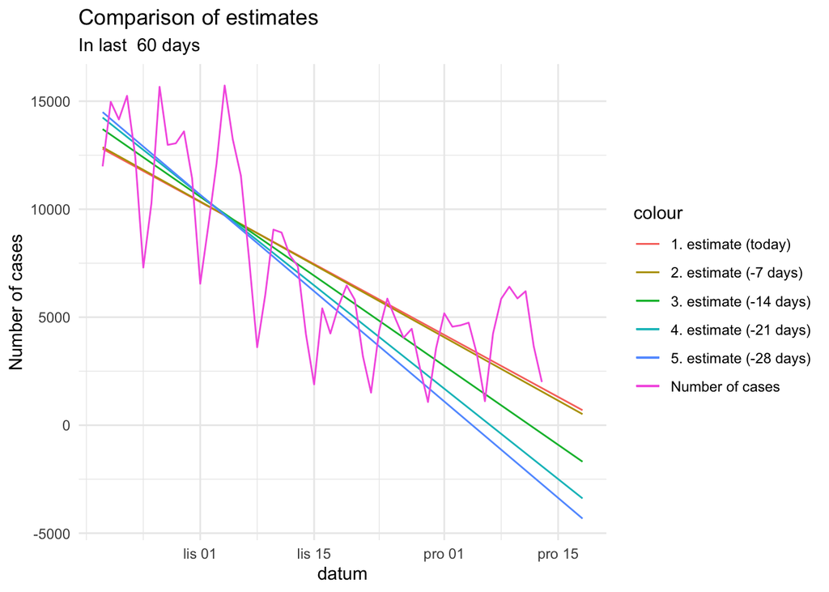

### Data (Linear model)

#### Since the beginning

According to this model, we should have on day `2020-12-18` based on estimates:

- 1. estimate `5637` daily confirmed cases.
- 2. estimate `5706` daily confirmed cases.
- 3. estimate `5778` daily confirmed cases.
- 4. estimate `5941` daily confirmed cases.
- 5. estimate `6081` daily confirmed cases.

#### In last `60` days

According to this model, we should have on day `2020-12-18` based on estimates:

- 1. estimate `695` daily confirmed cases.
- 2. estimate `512` daily confirmed cases.
- 3. estimate `-1689` daily confirmed cases.
- 4. estimate `-3389` daily confirmed cases.
- 5. estimate `-4322` daily confirmed cases.

## Quadratic model

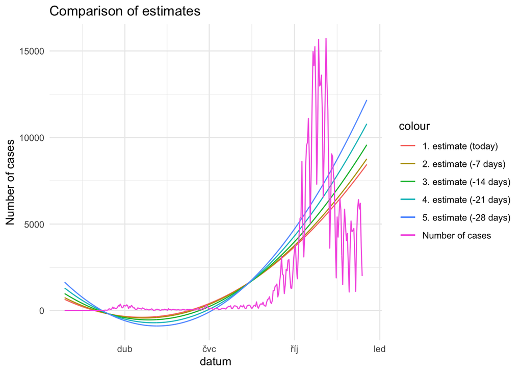

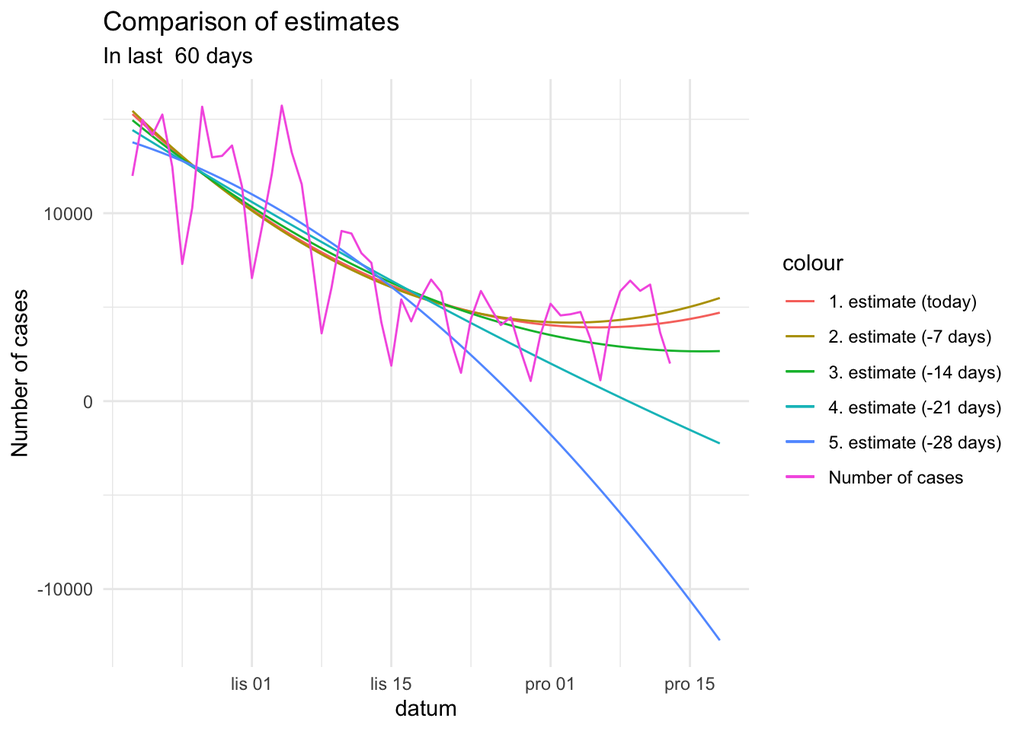

### Data (Quadratic model)

#### Since the beginning

According to this model, we should have on day `2020-12-18` based on estimates

- 1. estimate `8445` daily confirmed cases.
- 2. estimate `8767` daily confirmed cases.
- 3. estimate `9580` daily confirmed cases.
- 4. estimate `10792` daily confirmed cases.
- 5. estimate `12169` daily confirmed cases.

#### In last `60` days

According to this model, we should have on day `2020-12-18` based on estimates

- 1. estimate `4709` daily confirmed cases.
- 2. estimate `5490` daily confirmed cases.
- 3. estimate `2663` daily confirmed cases.
- 4. estimate `-2250` daily confirmed cases.
- 5. estimate `-12728` daily confirmed cases.

## Exponential model

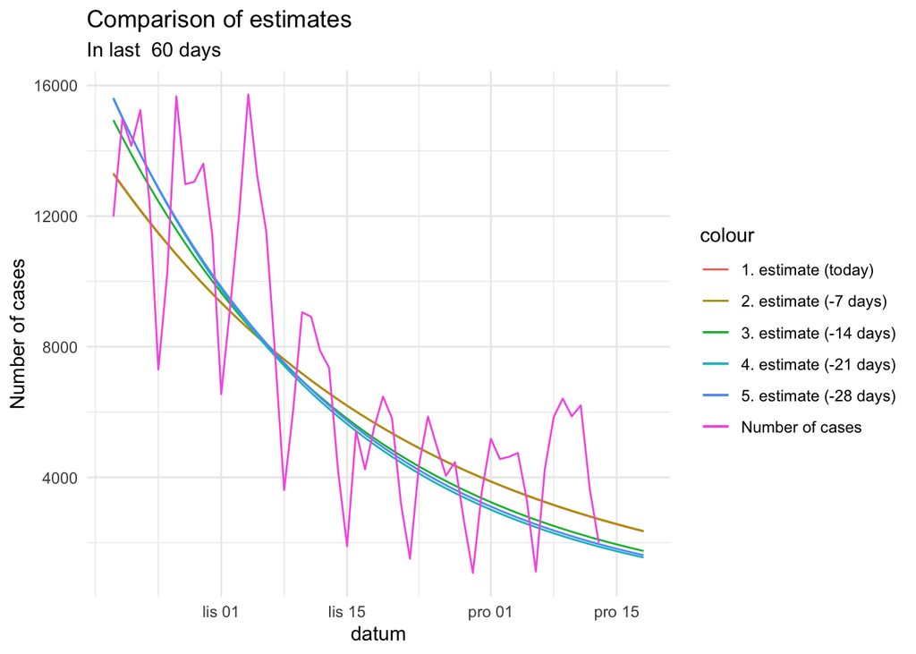

### Data (Exponential model)

#### In last `60` days

According to this model, we should have on day `2020-12-18` based on estimates

- 1. estimate `2345` daily confirmed cases.
- 2. estimate `2355` daily confirmed cases.
- 3. estimate `1745` daily confirmed cases.
- 4. estimate `1545` daily confirmed cases.
- 5. estimate `1615` daily confirmed cases.

According to this model, we should have on day `2020-12-14` based on estimates

- 1. estimate `2638` daily confirmed cases.
- 2. estimate `2648` daily confirmed cases.
- 3. estimate `2018` daily confirmed cases.
- 4. estimate `1807` daily confirmed cases.
- 5. estimate `1883` daily confirmed cases.

# Information

Last update: `2020-12-14 17:22:05`.

Newest data are from `2020-12-13` from the website of the Ministry of Health of Czech Republic (https://onemocneni-aktualne.mzcr.cz/covid-19)